# lab_7_key

Allison Horst

November 10, 2018

packages needed: tidyverse, magrittr data: gc_df.csv

### Lab Week 7

- GitHub continued (pulling, collaborating)
- Chi-square
- rank-based tests

Both of you: Create a folder called ‘github’ in your Home Directory (mac: top bar > Go > Home, PC: put it in My Documents)

# PART 1: Chi-square with a collaborator

1. Each person open up github
2. Choose a partner (can be groups of 3) - pick who will be ‘CREATOR’ and who will be ‘COLLABORATOR’ - write on a post-it note in front of you which one you are (can be groups of 3)

## CHI-SQUARE w/COLLABORATION

3.CREATOR: Log in to GitHub and create a new repo called ‘lab-7-chi-’YOURNAME’ (like ‘lab-7-chi-allison’)

4. CREATOR: Find the gc_df.csv file, and drop it into GitHub to upload (remember to press ‘Commit’)
5. CREATOR: Clone the project to RStudio (New Project > Version Control > Git > Paste URL > Tab > Navigate to ‘github’ folder > Create Project)
6. CREATOR: Open a new Rmarkdown document:
- Title: ‘Gun Control Chi-Square’
- Remove everything below first code chunk
- Add some introductory text:

“In this lab we’ll use chi-square to answer questions about Gun Control opinions based on sex, political ideology, and race.”

7. CREATOR: Stage, commit, and push back to GitHub
8. CREATOR: In GitHub, add a collaborator (Settings > Collaborators > (enter user name for collaborator))
9. CREATOR: Go back to RStudio, but don’t change anything yet
10. COLLABORATOR: You should get an EMAIL inviting you to be a collaborator on the repo. DO it. Check to make sure that now in your GitHub, you have the repo.
11. COLLABORATOR: Clone the repo to get it talking with RStudio (Clone > Copy URL > In RStudio: New Project > Version Control > Git > Paste URL > Tab > Navigate to ‘github’ folder > Create Project). Keep the RStudio project open, but don’t do anything.

**Important note here: once you have Cloned a project ONCE, you won’t need to do it again. From now on, to get updated information/files that have been pushed to the GitHub repo, you’ll use PULL (the down arrow).**

12. CREATOR: Let’s do some data science (collaborator, follow along but DO NOT TYPE in the cloned repo…)

```r
library(tidyverse) # Load tidyverse
library(magrittr)
gc_df <- read_csv("gc_df.csv") # Check out gun control data (from 2012 American National Election Study (ANES), accessed through http://sda.berkeley.edu/archive.htm)
# Some notes:

# Gender: should be sex
# make_get_guns: Should government make it harder, easier, same difficulty to get/buy guns?

# Make a contingency table:

get_guns <- gc_df %>%
  filter(gender != "NA", make_get_guns != "NA") %>%
  count(gender, make_get_guns) %>%
  spread(make_get_guns, n) %>%
  set_rownames(c("Female","Male")) %>%
  select(-gender)
# Tell it what variable you want to spread out into multiple columns (KEY), and what the values should be associated with it (Freq)...this is called a 'key-value pair'

# Now this looks like a contingency table.
```

13. CREATOR: At this point (after creating a contingency table), stage, commit and push back to GitHub.
14. BOTH: Refresh the repo and ensure that file has been updated (see new commit message/check updates/etc.)
15. COLLABORATOR: Notice that your files haven’t been updated in RStudio yet. Since you already have the repo cloned, all you need to do is ‘PULL’ (see down blue arrow in Git tab)…now you should see the new .Rmd show up. Click on it to open - now you can see what your partner just did to make the table!

**Notes: PULL FREQUENTLY to avoid conflicts (so that you have the most recent version), and COMMUNICATE WITH YOUR COLLABORATORS about what/when you’re working on different components!**

16. COLLABORATOR (CREATOR - DO NOTHING RIGHT NOW): In the .Rmd, create a new code chunk (add some text above it like “Now I’m going to use that contingency table to do chi-square”). In the code chunk, perform chi-square:

I’m a collaborator (Allison) and I’m adding this code chunk and response text:

```r
# We ask: "Is there a significant association between sex and opinion on whether the gvmt should make it more difficult, easier, or the same to get guns?"

# What we're really asking: Do PROPORTIONS of respondents who choose "make it more difficult","make it less difficult", or "same" to get guns differ between males and females?

# First, let's look at the actual proportions:

# Could also do this using the tidyverse, using group_by + mutate, but we'll use prop.table (which really wants thing in the class of 'matrix'):

guns_prop <- round(prop.table(as.matrix(get_guns),1),3)

# Perform chi-square test for independence (on the COUNT data - NOT on the proportions!)

guns_x2 <- chisq.test(get_guns)
guns_x2
```

```
##
##  Pearson's Chi-squared test
##
## data:  get_guns
## X-squared = 203.6, df = 2, p-value < 2.2e-16
```

```r
guns_x2$stdres # If beyond 2, pay attention for significance...
```

```
##           Easier More Difficult      Same
## Female -8.703648        13.0453 -9.126392
## Male    8.703648       -13.0453  9.126392
```

```r
# There IS a significant association between response and gender! Look at 'Values' section to see what things you can call from the output.
```

17. COLLABORATOR: SAVE, KNIT, and PUSH back to GitHub
18. CREATOR: PULL, then see updates in RStudio docs (like the .Rmd), add some text somewhere, then stage/commit/push…
19. COLLABORATOR: PULL, and see that the changes appear in your markdown document. Cool!
20. COLLABORATOR + CREATOR: Close this project!

## Always remember: if you’re collaborating, PULL OFTEN and STAY IN COMMUNICATION WITH YOUR COLLABORATORS!

# PART 2. Rank-based tests with a collaborator

## SWITCH POST-IT NOTES (switch roles)

1. CREATOR: Create a new repo in github called ‘lab-7-rank-’YOURNAME’ (like ‘lab-7-rank-allison’)
2. CREATOR: Drop the ‘kermit.csv’ file into the repo (make sure to commit)
3. CREATOR: Clone repo to RStudio
4. CREATOR: Go back to GitHub and add your partner as a collaborator using their github username
5. COLLABORATOR: Accept the invitation, then Clone to get it communicating with YOUR RStudio
6. CREATOR: Open a new RMarkdown document
- Title: ‘Kermit Perceptions Rank-Based Tests’
- Remove everything below first code chunk
- Type something in there (“Hi, my name is Blah”)
- Stage, commit, push back to git hub
7. COLLABORATOR: Pull. Notice that the markdown file is created. Open it.
8. COLLABORATOR: In a new code chunk, load the tidyverse and read in the kermit.csv data, and check out the dataset (Kermit rankings before and after Bren School presentation, did they watch shows, etc…)
9. COLLABORATOR: In a new code chunk, make histograms of kermit rankings (pre-Bren talk) for Male / Female students

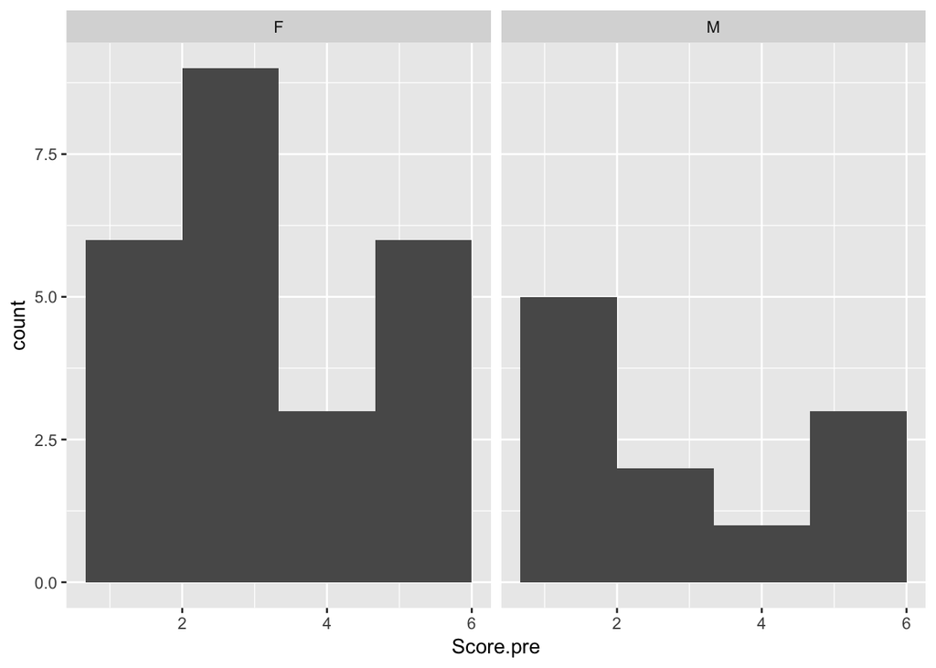

```r
kermit_hist <- ggplot(kermit, aes(x = Score.pre)) +
  geom_histogram(bins = 4) +
  facet_wrap(~ Gender)

kermit_hist
```

10. COLLABORATOR: Once graph is made, stage/commit/push back to github
11. CREATOR: Pull to get the updated markdown document. Cool, now all files and everything is in there. You’ll need to run the code to load the packages still (so run-all is a good option).
12. CREATOR: Insert a new code chunk to perform Mann-Whitney U to compare pre-presentation kermit rankings between M / F respondents:

```r
mwu_kermit <- kermit %>%
  wilcox.test(Score.pre ~ Gender, data = .)
mwu_kermit
```

```
##
##  Wilcoxon rank sum test with continuity correction
##
## data:  Score.pre by Gender
## W = 155.5, p-value = 0.4001
## alternative hypothesis: true location shift is not equal to 0
```

```r
# There is no significant difference in kermit ranks for Male and Female respondents.
```

There is no significant difference in pre-presentation Kermit ranks for male and female respondents (W = 155.5, *p* = 0.4000772, $\alpha = 0.05$)